# サービス産業

アセット･マネジメント･コンサルティング株式会社 http://am-consulting.co.jp

```
## Title : サービス産業動向調査 事業活動の産業別売上高(単位:億円) 2016年6月
## Raw Data Source : 総務省
## Author : アセット･マネジメント･コンサルティング株式会社 http://am-consulting.co.jp
## 作成日 : 2016-08-31 16:15:42
## 特記 : 複数のワードで検索する際は半角スペースで区切ってください
## 特記 : 表中、-9999はNAを意味します
```

**サービス産業動向調査 事業活動の産業別売上高(単位:億円) 2016年6月 2013-01~2016-06 . Powered By https://www.amcharts.com/**

[interactive chart not shown]

### サービス産業動向調査 事業活動の産業別売上高(単位:億円) 2016年6月-原系列

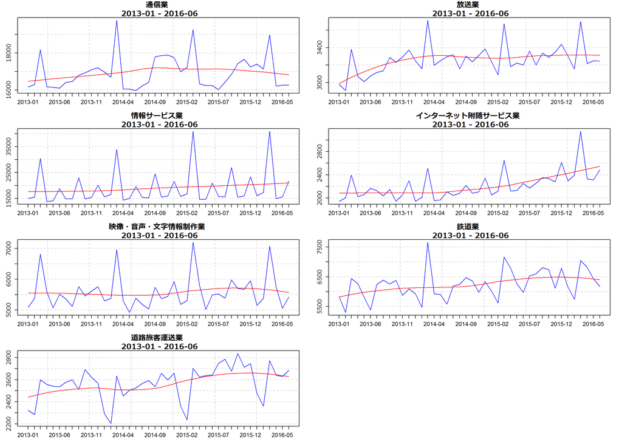

### サービス産業動向調査 事業活動の産業別売上高(単位:億円) 2016年6月-原系列

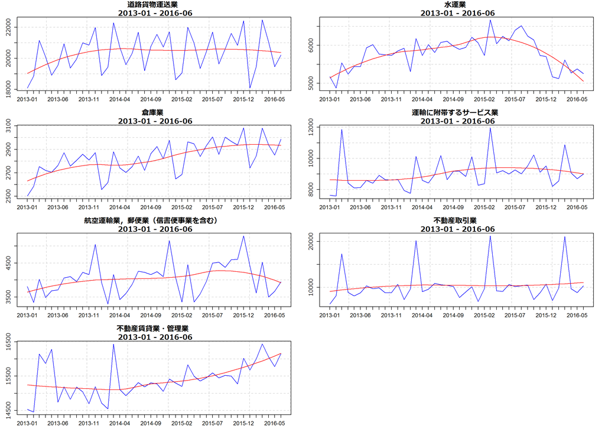

### サービス産業動向調査 事業活動の産業別売上高(単位:億円) 2016年6月-原系列

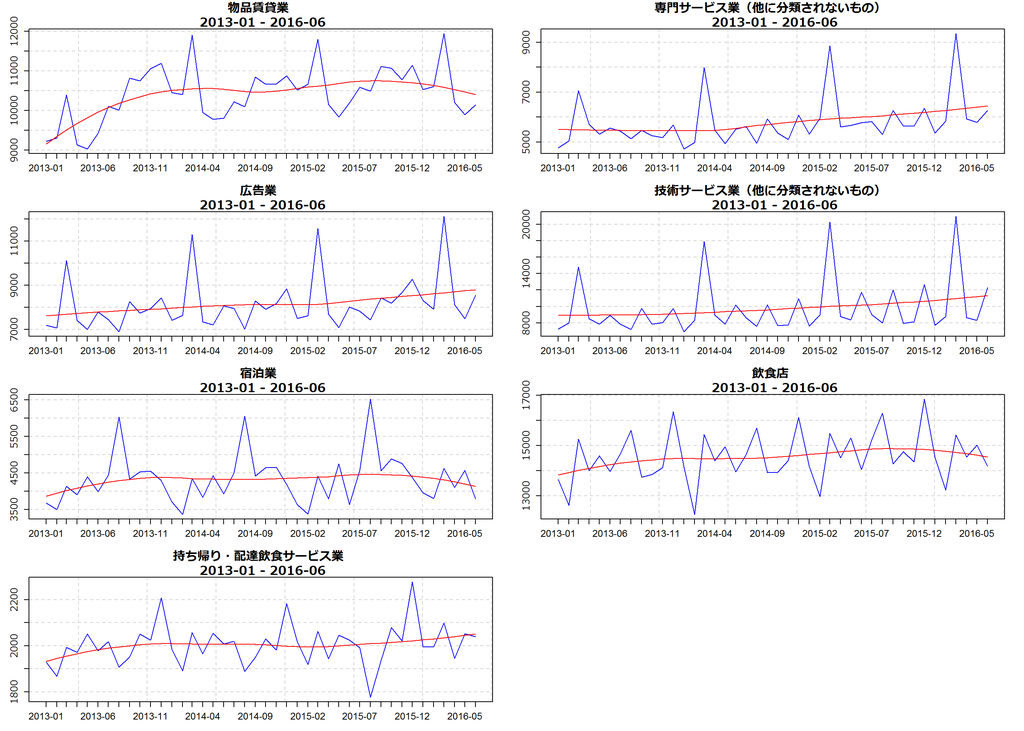

### サービス産業動向調査 事業活動の産業別売上高(単位:億円) 2016年6月-原系列

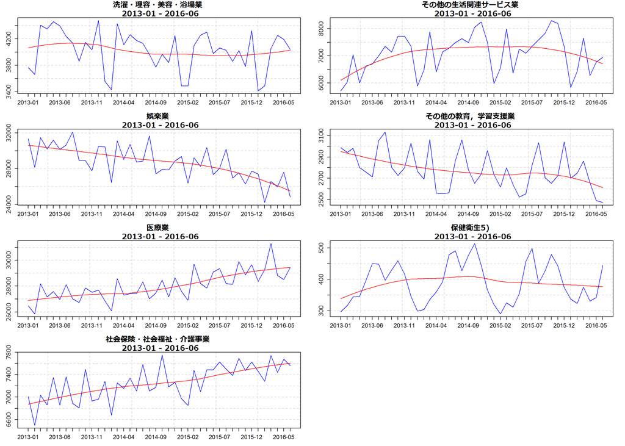

### サービス産業動向調査 事業活動の産業別売上高(単位:億円) 2016年6月-原系列

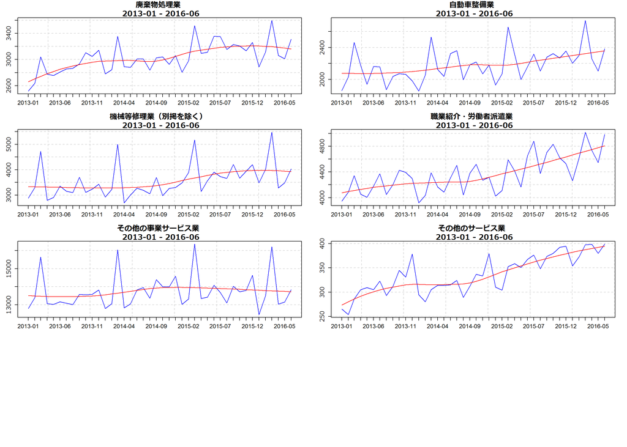

### サービス産業動向調査 事業活動の産業別売上高(単位:億円) 2016年6月-前年同月比(%)

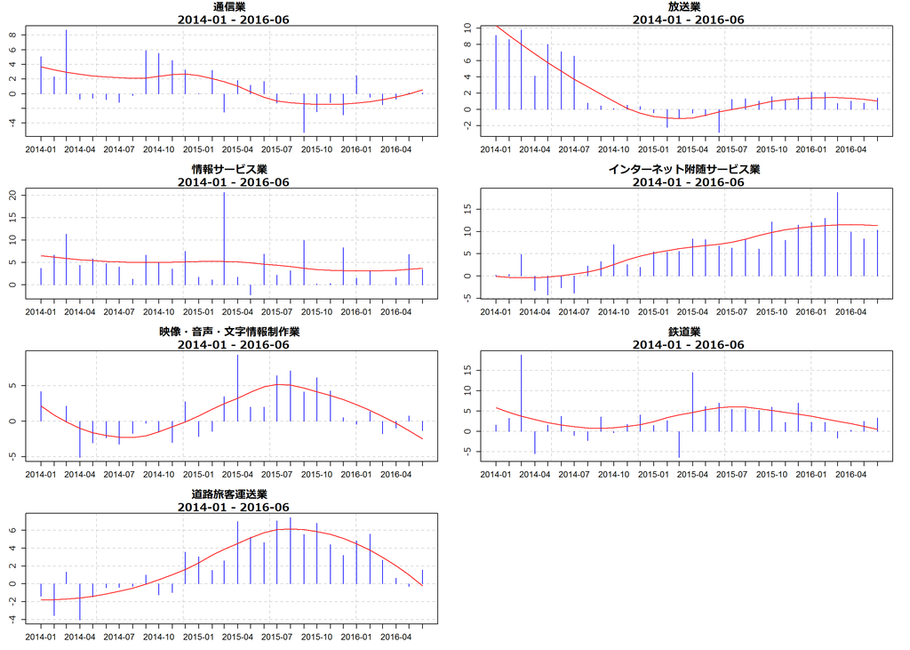

### サービス産業動向調査 事業活動の産業別売上高(単位:億円) 2016年6月-前年同月比(%)

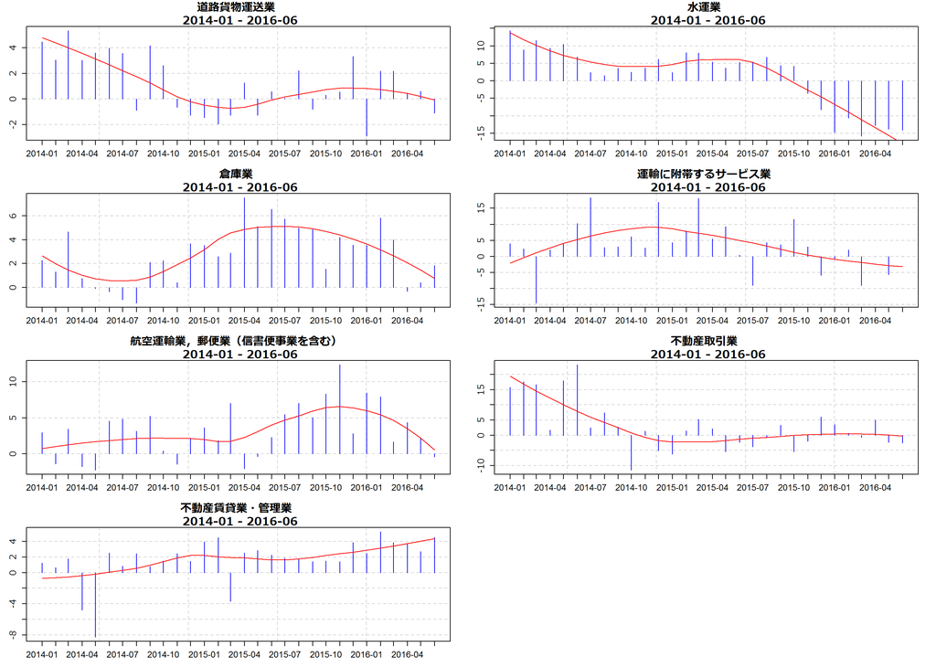

### サービス産業動向調査 事業活動の産業別売上高(単位:億円) 2016年6月-前年同月比(%)

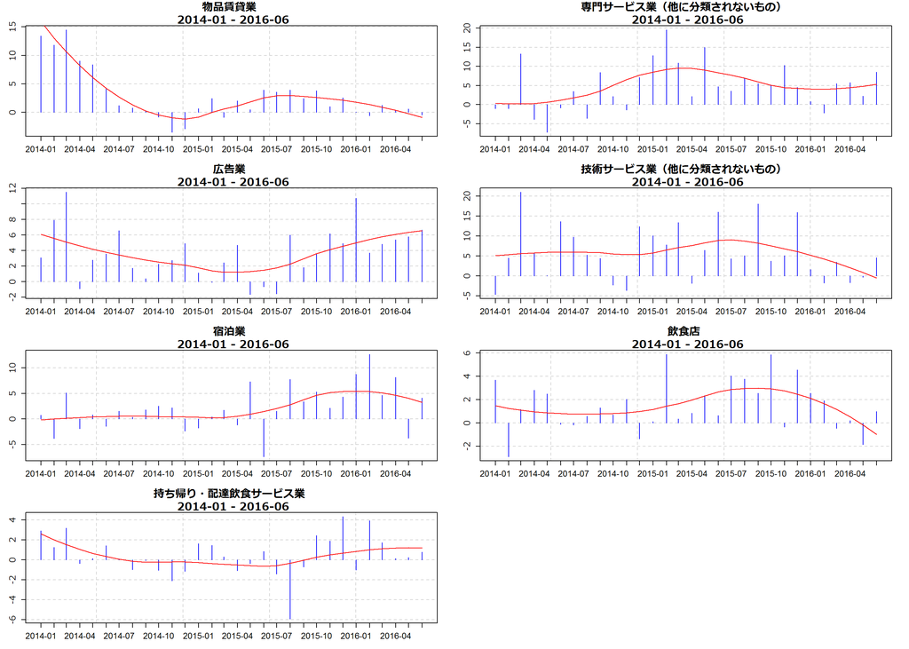

### サービス産業動向調査 事業活動の産業別売上高(単位:億円) 2016年6月-前年同月比(%)

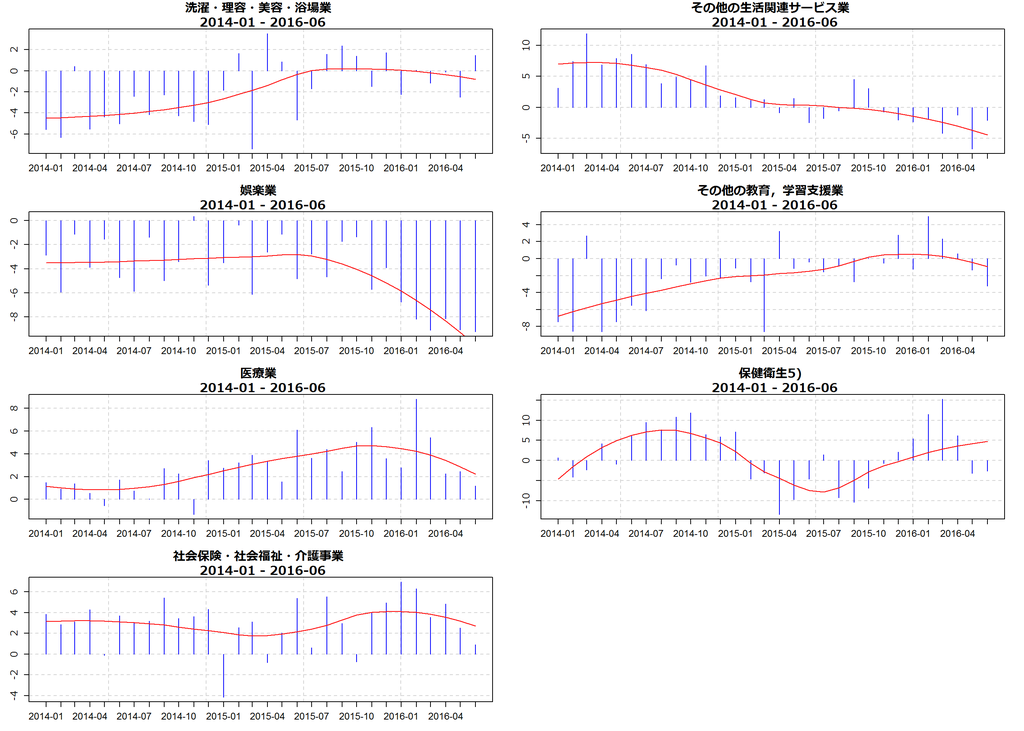

### サービス産業動向調査 事業活動の産業別売上高(単位:億円) 2016年6月-前年同月比(%)

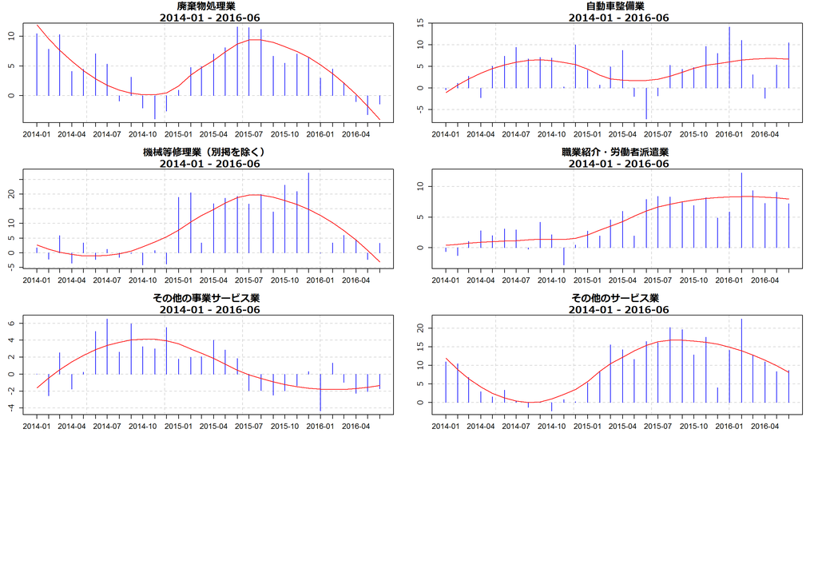

| ID | 項目 | 2016-02 | 2016-03 | 2016-04 | 2016-05 | 2016-06 |
| --- | --- | --- | --- | --- | --- | --- |
| 1 | 通信業 | 17135.77 | 18979.57 | 16220.26 | 16262.38 | 16269.83 |
| 2 | 放送業 | 3155.64 | 3699.31 | 3215.87 | 3250.88 | 3245.73 |
| 3 | 情報サービス業 | 17321.57 | 40919.66 | 14936.63 | 15645.33 | 21747.07 |
| 4 | インターネット附随サービス業 | 2395.92 | 3148.13 | 2329.87 | 2309.95 | 2485.31 |
| 5 | 映像・音声・文字情報制作業 | 5375.31 | 7072.93 | 5745.35 | 5052.24 | 5420.2 |
| 6 | 鉄道業 | 5744 | 7050.43 | 6815.13 | 6432.62 | 6172.69 |
| 7 | 道路旅客運送業 | 2361.01 | 2773.44 | 2641.75 | 2628.83 | 2684.84 |
| 8 | 道路貨物運送業 | 19469.46 | 22487.22 | 21065.55 | 19465.33 | 20220.23 |
| 9 | 水運業 | 5124.79 | 5615.5 | 5273.12 | 5378.44 | 5256.59 |
| 10 | 倉庫業 | 2842.77 | 3082.03 | 2938.07 | 2851.47 | 2987.17 |

[output cut: 24 more lines]

| ID | 項目 | 2016-02 | 2016-03 | 2016-04 | 2016-05 | 2016-06 |
| --- | --- | --- | --- | --- | --- | --- |
| 1 | 通信業 | -0.5 | -1.5 | -0.77 | 0.1 | 0.14 |
| 2 | 放送業 | 2.13 | 0.75 | 1.03 | 0.77 | 1.39 |
| 3 | 情報サービス業 | 3.13 | 0 | 1.68 | 6.84 | 3.36 |
| 4 | インターネット附随サービス業 | 13.02 | 18.82 | 9.88 | 8.34 | 10.38 |
| 5 | 映像・音声・文字情報制作業 | 1.35 | -1.77 | -0.95 | 0.73 | -1.36 |
| 6 | 鉄道業 | 2.25 | -1.65 | 0.33 | 2.55 | 3.32 |
| 7 | 道路旅客運送業 | 5.57 | 2.67 | 0.66 | -0.29 | 1.56 |
| 8 | 道路貨物運送業 | 2.19 | 2.18 | 0.45 | 0.6 | -1.1 |
| 9 | 水運業 | -10.64 | -15.83 | -12.72 | -13.76 | -14.09 |
| 10 | 倉庫業 | 5.84 | 3.99 | -0.33 | 0.39 | 1.84 |

[output cut: 24 more lines]